# The_Analytics_Edge_edX_MIT15.071x_June2015

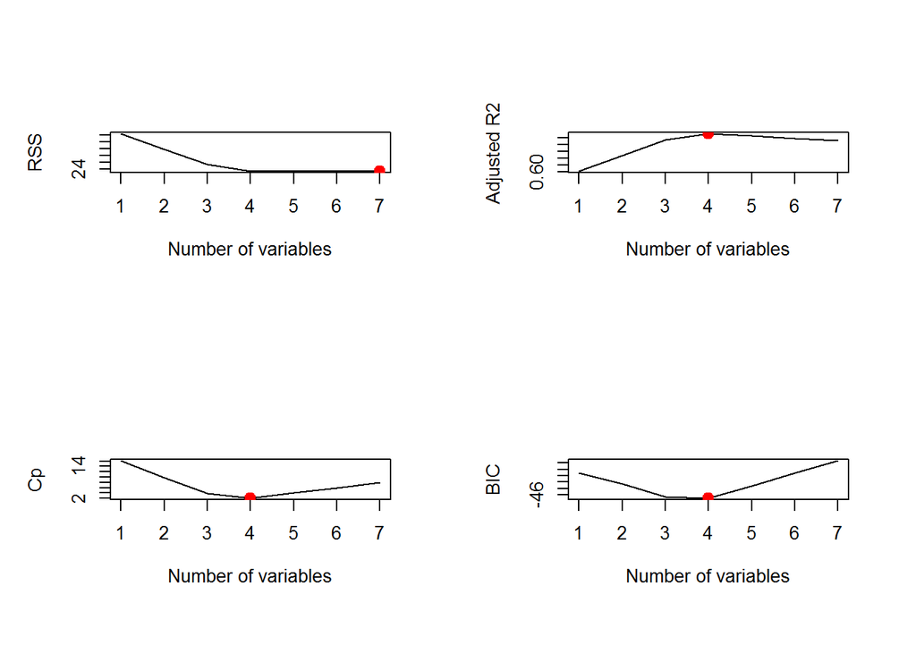

```r
points(4,reg.summary$bic[4],col="red",cex=2,pch=20) # adding the point to the plot which shows the min Cp
```

```r
#So we know now that 4 var model is the best model as per backward selection method based on Cp/Adj Rsqr/BIC
reg.summary$which #A logical matrix indicating which elements are in each model
```

```
##   (Intercept) Population Income Illiteracy Murder HS.Grad Frost  Area
## 1        TRUE      FALSE  FALSE      FALSE   TRUE   FALSE FALSE FALSE
## 2        TRUE      FALSE  FALSE      FALSE   TRUE    TRUE FALSE FALSE
## 3        TRUE      FALSE  FALSE      FALSE   TRUE    TRUE  TRUE FALSE
## 4        TRUE       TRUE  FALSE      FALSE   TRUE    TRUE  TRUE FALSE
## 5        TRUE       TRUE   TRUE      FALSE   TRUE    TRUE  TRUE FALSE
## 6        TRUE       TRUE   TRUE       TRUE   TRUE    TRUE  TRUE FALSE
## 7        TRUE       TRUE   TRUE       TRUE   TRUE    TRUE  TRUE  TRUE
```

```r
#Ans:Population,Murder,HS.Grad,Frost

#EXPLANATION;

#Lets see the backward selection method wherein we start with the full model and start eliminating var one by one based on highest P-value citerion (least significant var eliminated first but done one by one ).
LinReg<-lm(Life.Exp~Population+Income+Illiteracy+Murder+HS.Grad+Frost+Area,data=statedata) #full model
summary(LinReg)
```

```
##
## Call:
## lm(formula = Life.Exp ~ Population + Income + Illiteracy + Murder +
##     HS.Grad + Frost + Area, data = statedata)
##
## Residuals:
##      Min       1Q   Median       3Q      Max
## -1.48895 -0.51232 -0.02747  0.57002  1.49447
##
## Coefficients:
##               Estimate Std. Error t value Pr(>|t|)
## (Intercept)  7.094e+01  1.748e+00  40.586  < 2e-16 ***
## Population   5.180e-05  2.919e-05   1.775   0.0832 .
## Income      -2.180e-05  2.444e-04  -0.089   0.9293
## Illiteracy   3.382e-02  3.663e-01   0.092   0.9269
## Murder      -3.011e-01  4.662e-02  -6.459 8.68e-08 ***
## HS.Grad      4.893e-02  2.332e-02   2.098   0.0420 *
## Frost       -5.735e-03  3.143e-03  -1.825   0.0752 .
## Area        -7.383e-08  1.668e-06  -0.044   0.9649
## ---
## Signif. codes:  0 '***' 0.001 '**' 0.01 '*' 0.05 '.' 0.1 ' ' 1
##
## Residual standard error: 0.7448 on 42 degrees of freedom
## Multiple R-squared:  0.7362, Adjusted R-squared:  0.6922
## F-statistic: 16.74 on 7 and 42 DF,  p-value: 2.534e-10
```

```r
#We would eliminate the variable "Area" first (since it has the highest p-value, or probability, with a value of 0.9649), by adjusting our lm command to the following:
LinReg = lm(Life.Exp ~ Population + Income + Illiteracy + Murder + HS.Grad + Frost, data=statedata)
summary(LinReg)
```

```
##
## Call:
## lm(formula = Life.Exp ~ Population + Income + Illiteracy + Murder +
##     HS.Grad + Frost, data = statedata)
##
## Residuals:
##      Min       1Q   Median       3Q      Max
## -1.49047 -0.52533 -0.02546  0.57160  1.50374
##
## Coefficients:
##               Estimate Std. Error t value Pr(>|t|)
## (Intercept)  7.099e+01  1.387e+00  51.165  < 2e-16 ***
## Population   5.188e-05  2.879e-05   1.802   0.0785 .
## Income      -2.444e-05  2.343e-04  -0.104   0.9174
## Illiteracy   2.846e-02  3.416e-01   0.083   0.9340
## Murder      -3.018e-01  4.334e-02  -6.963 1.45e-08 ***
## HS.Grad      4.847e-02  2.067e-02   2.345   0.0237 *
## Frost       -5.776e-03  2.970e-03  -1.945   0.0584 .
## ---
## Signif. codes:  0 '***' 0.001 '**' 0.01 '*' 0.05 '.' 0.1 ' ' 1
##
## Residual standard error: 0.7361 on 43 degrees of freedom
## Multiple R-squared:  0.7361, Adjusted R-squared:  0.6993
## F-statistic: 19.99 on 6 and 43 DF,  p-value: 5.362e-11
```

```r
#Looking at summary(LinReg) now, we would choose to eliminate "Illiteracy" since it now has the highest p-value of 0.9340, using the following command:
LinReg = lm(Life.Exp ~ Population + Income + Murder + HS.Grad + Frost, data=statedata)
summary(LinReg)
```

```
##
## Call:
## lm(formula = Life.Exp ~ Population + Income + Murder + HS.Grad +
##     Frost, data = statedata)
##
## Residuals:
##     Min      1Q  Median      3Q     Max
## -1.4892 -0.5122 -0.0329  0.5645  1.5166
##
## Coefficients:
##               Estimate Std. Error t value Pr(>|t|)
## (Intercept)  7.107e+01  1.029e+00  69.067  < 2e-16 ***
## Population   5.115e-05  2.709e-05   1.888   0.0657 .
## Income      -2.477e-05  2.316e-04  -0.107   0.9153
## Murder      -3.000e-01  3.704e-02  -8.099 2.91e-10 ***
## HS.Grad      4.776e-02  1.859e-02   2.569   0.0137 *
## Frost       -5.910e-03  2.468e-03  -2.395   0.0210 *
## ---
## Signif. codes:  0 '***' 0.001 '**' 0.01 '*' 0.05 '.' 0.1 ' ' 1
##
## Residual standard error: 0.7277 on 44 degrees of freedom
## Multiple R-squared:  0.7361, Adjusted R-squared:  0.7061
## F-statistic: 24.55 on 5 and 44 DF,  p-value: 1.019e-11
```

```r
#Looking at summary(LinReg) again, we would next choose to eliminate "Income", since it has a p-value of 0.9153. This gives the following four variable model:
LinReg = lm(Life.Exp ~ Population + Murder + HS.Grad + Frost, data=statedata)
summary(LinReg)
```

```
##
## Call:
## lm(formula = Life.Exp ~ Population + Murder + HS.Grad + Frost,
##     data = statedata)
##
## Residuals:
##      Min       1Q   Median       3Q      Max
## -1.47095 -0.53464 -0.03701  0.57621  1.50683
##
## Coefficients:
##               Estimate Std. Error t value Pr(>|t|)
## (Intercept)  7.103e+01  9.529e-01  74.542  < 2e-16 ***
## Population   5.014e-05  2.512e-05   1.996  0.05201 .
## Murder      -3.001e-01  3.661e-02  -8.199 1.77e-10 ***
## HS.Grad      4.658e-02  1.483e-02   3.142  0.00297 **
## Frost       -5.943e-03  2.421e-03  -2.455  0.01802 *
## ---
## Signif. codes:  0 '***' 0.001 '**' 0.01 '*' 0.05 '.' 0.1 ' ' 1
##
## Residual standard error: 0.7197 on 45 degrees of freedom
## Multiple R-squared:  0.736,  Adjusted R-squared:  0.7126
## F-statistic: 31.37 on 4 and 45 DF,  p-value: 1.696e-12
```

```r
#This model with 4 variables is a good model. However, we can see that the variable "Population" is not quite significant. In practice, it would be up to you whether or not to keep the variable "Population" or eliminate it for a 3-variable model. Population does not add much statistical significance in the presence of murder, high school graduation rate, and frost days. However, for the remainder of this question, we will analyze the 4-variable model.

# This entire backward selection steps can be easily done using regsubsets() in leaps library

##################################

#PROBLEM 3.2 - PREDICTING LIFE EXPECTANCY - REFINING THE MODEL AND ANALYZING PREDICTIONS

#Removing insignificant variables changes the Multiple R-squared value of the model. By looking at the summary output for both the initial model (all independent variables) and the simplified model (only 4 independent variables) and using what you learned in class, which of the following correctly explains the change in the Multiple R-squared value?
#Ans:We expect the "Multiple R-squared" value of the simplified model to be slightly worse than that of the initial model. It can't be better than the "Multiple R-squared" value of the initial model.

#EXPLANATION:When we remove insignificant variables, the "Multiple R-squared" will always be worse, but only slightly worse. This is due to the nature of a linear regression model. It is always possible for the regression model to make a coefficient zero, which would be the same as removing the variable from the model. The fact that the coefficient is not zero in the intial model means it must be helping the R-squared value, even if it is only a very small improvement. So when we force the variable to be removed, it will decrease the R-squared a little bit. However, this small decrease is worth it to have a simpler model.
#On the contrary, when we remove insignificant variables, the "Adjusted R-squred" will frequently be better. This value accounts for the complexity of the model, and thus tends to increase as insignificant variables are removed, and decrease as insignificant variables are added.

##########################################

#PROBLEM 3.3 - PREDICTING LIFE EXPECTANCY - REFINING THE MODEL AND ANALYZING PREDICTIONS

#Using the simplified 4 variable model that we created, we'll now take a look at how our predictions compare to the actual values.

#Take a look at the vector of predictions by using the predict function (since we are just looking at predictions on the training set, you don't need to pass a "newdata" argument to the predict function).

#Which state do we predict to have the lowest life expectancy? (Hint: use the sort function)

predTest<-predict(LinReg)
sort(predTest)
```

```
##        Alabama        Georgia    Mississippi South Carolina      Louisiana
##       68.48112       68.63694       69.00535       69.06109       69.15045
##       Kentucky North Carolina      Tennessee         Nevada       Arkansas
##       69.24418       69.28624       69.46583       69.52482       69.57374
##         Alaska       Michigan          Texas     New Mexico       Missouri
##       69.85740       69.86893       69.97886       70.03119       70.10610
##       Virginia       Illinois  West Virginia       Maryland        Florida
##       70.14691       70.19244       70.44983       70.51852       70.61539
##       New York        Wyoming        Indiana        Vermont           Ohio
##       70.62937       70.87679       70.90159       71.06135       71.08549
##       Colorado       Delaware       Oklahoma   Pennsylvania        Montana
##       71.10354       71.12647       71.15860       71.38046       71.40025
##        Arizona          Idaho     New Jersey  New Hampshire   Rhode Island
##       71.41416       71.49989       71.59612       71.72636       71.76007
##     California          Maine   North Dakota         Kansas      Wisconsin
##       71.79565       71.86095       71.87649       71.90352       72.00996
##   South Dakota    Connecticut           Utah         Hawaii       Nebraska
##       72.01161       72.03459       72.05753       72.09317       72.17032
##      Minnesota           Iowa         Oregon  Massachusetts     Washington
##       72.26560       72.39653       72.41445       72.44105       72.68272
```

```r
#Ans:Alabama

#Which state actually has the lowest life expectancy? (Hint: use the which.min function)
statedata$state.name[which.min(statedata$Life.Exp)]
```

```
## [1] South Carolina
## 50 Levels: Alabama Alaska Arizona Arkansas California ... Wyoming
```

```r
#Ans: South Carolina

#################################

#PROBLEM 3.4 - PREDICTING LIFE EXPECTANCY - REFINING THE MODEL AND ANALYZING PREDICTIONS

#Which state do we predict to have the highest life expectancy?
sort(predTest,decreasing = T)
```

```
##     Washington  Massachusetts         Oregon           Iowa      Minnesota
##       72.68272       72.44105       72.41445       72.39653       72.26560
##       Nebraska         Hawaii           Utah    Connecticut   South Dakota
##       72.17032       72.09317       72.05753       72.03459       72.01161
##      Wisconsin         Kansas   North Dakota          Maine     California
##       72.00996       71.90352       71.87649       71.86095       71.79565
##   Rhode Island  New Hampshire     New Jersey          Idaho        Arizona
##       71.76007       71.72636       71.59612       71.49989       71.41416
##        Montana   Pennsylvania       Oklahoma       Delaware       Colorado
##       71.40025       71.38046       71.15860       71.12647       71.10354
##           Ohio        Vermont        Indiana        Wyoming       New York
##       71.08549       71.06135       70.90159       70.87679       70.62937
##        Florida       Maryland  West Virginia       Illinois       Virginia
##       70.61539       70.51852       70.44983       70.19244       70.14691
##       Missouri     New Mexico          Texas       Michigan         Alaska
##       70.10610       70.03119       69.97886       69.86893       69.85740
##       Arkansas         Nevada      Tennessee North Carolina       Kentucky
##       69.57374       69.52482       69.46583       69.28624       69.24418
##      Louisiana South Carolina    Mississippi        Georgia        Alabama
##       69.15045       69.06109       69.00535       68.63694       68.48112
```

```r
#Ans: Washington

#Which state actually has the highest life expectancy?
statedata$state.name[which.max(statedata$Life.Exp)]
```

```
## [1] Hawaii
## 50 Levels: Alabama Alaska Arizona Arkansas California ... Wyoming
```

```r
#Ans: Hawaii

##################################

#PROBLEM 3.5 - PREDICTING LIFE EXPECTANCY - REFINING THE MODEL AND ANALYZING PREDICTIONS

#Take a look at the vector of residuals (the difference between the predicted and actual values).
sort(abs(LinReg$residuals)) #or sort(abs(predTest-statedata$Life.Exp))
```

```
##        Indiana        Florida       Illinois       Virginia   South Dakota
##     0.02158526     0.04460505     0.05244160     0.06691392     0.06839119
## North Carolina       New York     California        Georgia   Rhode Island
##     0.07624179     0.07937149     0.08564599     0.09694227     0.13992982
##           Iowa       Oklahoma           Ohio         Oregon     New Mexico
##     0.16347124     0.26139958     0.26548767     0.28445333     0.28880945
##       Maryland          Idaho      Louisiana       Nebraska    Connecticut
##     0.29851996     0.37010714     0.39044846     0.42967691     0.44541028
##      Wisconsin         Nevada  New Hampshire         Alaska        Alabama
##     0.47004324     0.49482393     0.49635615     0.54740399     0.56888134
##        Vermont       Missouri        Wyoming  Massachusetts      Tennessee
##     0.57865019     0.58389969     0.58678863     0.61105391     0.64416651
##     New Jersey         Kansas      Minnesota       Michigan        Montana
##     0.66612086     0.67648037     0.69440380     0.76106640     0.84024805
##           Utah       Kentucky        Arizona   North Dakota    Mississippi
##     0.84246817     0.85582067     0.86415671     0.90350550     0.91535384
##          Texas   Pennsylvania       Colorado     Washington  West Virginia
##     0.92114057     0.95045527     0.95645816     0.96272426     0.96982588
##       Delaware       Arkansas South Carolina          Maine         Hawaii
##     1.06646884     1.08626119     1.10109172     1.47095411     1.50683146
```

```r
#For which state do we make the smallest absolute error?
#Ans:Indiana

#For which state do we make the largest absolute error?
sort(abs(LinReg$residuals),decreasing = T ) #or sort(abs(predTest-statedata$Life.Exp),decreasing = T)
```

```
##         Hawaii          Maine South Carolina       Arkansas       Delaware
##     1.50683146     1.47095411     1.10109172     1.08626119     1.06646884
##  West Virginia     Washington       Colorado   Pennsylvania          Texas
##     0.96982588     0.96272426     0.95645816     0.95045527     0.92114057
##    Mississippi   North Dakota        Arizona       Kentucky           Utah
##     0.91535384     0.90350550     0.86415671     0.85582067     0.84246817
##        Montana       Michigan      Minnesota         Kansas     New Jersey
##     0.84024805     0.76106640     0.69440380     0.67648037     0.66612086
##      Tennessee  Massachusetts        Wyoming       Missouri        Vermont
##     0.64416651     0.61105391     0.58678863     0.58389969     0.57865019
##        Alabama         Alaska  New Hampshire         Nevada      Wisconsin
##     0.56888134     0.54740399     0.49635615     0.49482393     0.47004324
##    Connecticut       Nebraska      Louisiana          Idaho       Maryland
##     0.44541028     0.42967691     0.39044846     0.37010714     0.29851996
##     New Mexico         Oregon           Ohio       Oklahoma           Iowa
##     0.28880945     0.28445333     0.26548767     0.26139958     0.16347124
##   Rhode Island        Georgia     California       New York North Carolina
##     0.13992982     0.09694227     0.08564599     0.07937149     0.07624179
##   South Dakota       Virginia       Illinois        Florida        Indiana
##     0.06839119     0.06691392     0.05244160     0.04460505     0.02158526
```

```r
#Ans: Hawaii
```

### Assignment 2: FORECASTING ELANTRA SALES (OPTIONAL)

FORECASTING ELANTRA SALES (OPTIONAL)

An important application of linear regression is understanding sales. Consider a company that produces and sells a product. In a given period, if the company produces more units than how many consumers will buy, the company will not earn money on the unsold units and will incur additional costs due to having to store those units in inventory before they can be sold. If it produces fewer units than how many consumers will buy, the company will earn less than it potentially could have earned. Being able to predict consumer sales, therefore, is of first order importance to the company.

In this problem, we will try to predict monthly sales of the Hyundai Elantra in the United States. The Hyundai Motor Company is a major automobile manufacturer based in South Korea. The Elantra is a car model that has been produced by Hyundai since 1990 and is sold all over the world, including the United States. We will build a linear regression model to predict monthly sales using economic indicators of the United States as well as Google search queries.

The file elantra.csv contains data for the problem. Each observation is a month, from January 2010 to February 2014.

```r
#lets import the data set
Elantra<-read.csv("elantra.csv")
str(Elantra)
```

```
## 'data.frame':    50 obs. of  7 variables:
##  $ Month       : int  1 1 1 1 1 2 2 2 2 2 ...
##  $ Year        : int  2010 2011 2012 2013 2014 2010 2011 2012 2013 2014 ...
##  $ ElantraSales: int  7690 9659 10900 12174 15326 7966 12289 13820 16219 16393 ...
##  $ Unemployment: num  9.7 9.1 8.2 7.9 6.6 9.8 9 8.3 7.7 6.7 ...
##  $ Queries     : int  153 259 354 230 232 130 266 296 239 240 ...
##  $ CPI_energy  : num  213 229 244 243 248 ...
##  $ CPI_all     : num  217 221 228 231 235 ...
```

```r
#PROBLEM 1 - LOADING THE DATA

#lets split the data set into training & test data set

#Load the data set. Split the data set into training and testing sets as follows: place all observations for 2012 and earlier in the training set, and all observations for 2013 and 2014 into the testing set.

ElantraTrain<-subset(Elantra,Year<=2012)
dim(ElantraTrain)
```

```
## [1] 36  7
```

```r
ElantraTest<-subset(Elantra,Year>2012) #or ElantraTest<-subset(Elantra,Year==2013 | Year==2014)
dim(ElantraTest)
```

```
## [1] 14  7
```

```r
#How many observations are in the training set?
#Ans:36

##################################################

#PROBLEM 2.1 - A LINEAR REGRESSION MODEL

#Build a linear regression model to predict monthly Elantra sales using Unemployment, CPI_all, CPI_energy and Queries as the independent variables. Use all of the training set data to do this.

ElantraLM<-lm(ElantraSales~Unemployment+CPI_all+CPI_energy +Queries,data=ElantraTrain)
summary(ElantraLM)
```

```
##
## Call:
## lm(formula = ElantraSales ~ Unemployment + CPI_all + CPI_energy +
##     Queries, data = ElantraTrain)
##
## Residuals:
##     Min      1Q  Median      3Q     Max
## -6785.2 -2101.8  -562.5  2901.7  7021.0
##
## Coefficients:
##               Estimate Std. Error t value Pr(>|t|)
## (Intercept)   95385.36  170663.81   0.559    0.580
## Unemployment  -3179.90    3610.26  -0.881    0.385
## CPI_all        -297.65     704.84  -0.422    0.676
## CPI_energy       38.51     109.60   0.351    0.728
## Queries          19.03      11.26   1.690    0.101
##
## Residual standard error: 3295 on 31 degrees of freedom
## Multiple R-squared:  0.4282, Adjusted R-squared:  0.3544
## F-statistic: 5.803 on 4 and 31 DF,  p-value: 0.00132
```

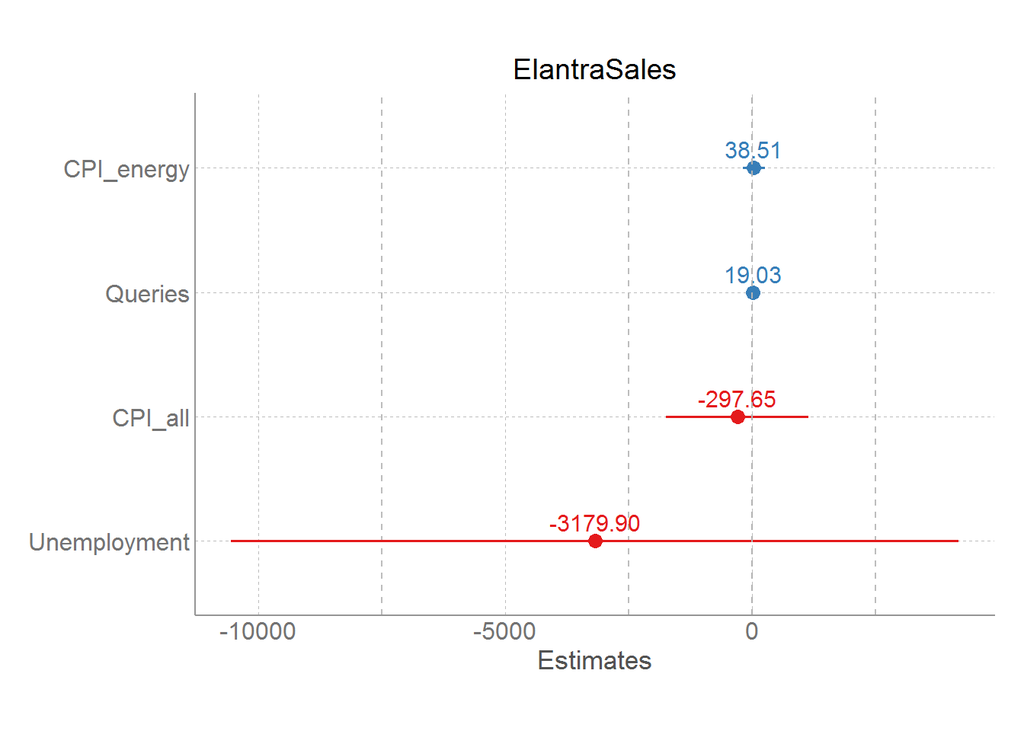

```r
#lets visualise the coeff using sjPlot package
library(sjPlot)
sjp.lm(ElantraLM)
```

```r
#What is the model R-squared? Note: In this problem, we will always be asking for the "Multiple R-Squared" of the model.
#Ans: 0.4282

###############################################

#PROBLEM 2.2 - SIGNIFICANT VARIABLES


#How many variables are significant, or have levels that are significant? Use 0.10 as your p-value cutoff.
#Ans:0
#EXPLANATION:After obtaining the output of the model summary, simply look at the p-values of all of the variables in the output (the right-most column, labeled "Pr(>|t|)"). It turns out that none of them are significant.



########################################

#PROBLEM 2.3 - COEFFICIENTS

#What is the coefficient of the Unemployment variable?
summary(ElantraLM)$coefficients["Unemployment","Estimate"]
```

```
## [1] -3179.9
```

```r
#or coef(summary(ElantraLM))["Unemployment","Estimate"]
#Ans:-3179.9

####################################

#PROBLEM 2.4 - INTERPRETING THE COEFFICIENT

#What is the interpretation of this coefficient?
#Ans:For an increase of 1 in Unemployment, the prediction of Elantra sales decreases by approximately 3000.
#EXPLANATION:The second choice is the correct answer; the coefficient is defined as the change in the prediction of the dependent variable (ElantraSales) per unit change in the independent variable in question (Unemployment). The first choice is therefore not correct; it also does not make intuitive sense since Unemployment is the percentage unemployment rate, which is bounded to be between 0 and 100.
#The third choice is not correct because the coefficient indicates how the prediction changes, not how the actual sales change, and this option asserts that actual sales change, i.e., there is a causal effect.
#The fourth choice is not correct because the statistical significance indicates how likely it is that, by chance, the true coefficient is not different from zero. However, the estimated coefficient still has a (non-zero) value, and our prediction will change for different values of Unemployment; therefore, the sales prediction cannot stay the same.

#########################################

#PROBLEM 3.1 - MODELING SEASONALITY

#Our model R-Squared is relatively low, so we would now like to improve our model. In modeling demand and sales, it is often useful to model seasonality. Seasonality refers to the fact that demand is often cyclical/periodic in time. For example, in countries with different seasons, demand for warm outerwear (like jackets and coats) is higher in fall/autumn and winter (due to the colder weather) than in spring and summer. (In contrast, demand for swimsuits and sunscreen is higher in the summer than in the other seasons.) Another example is the "back to school" period in North America: demand for stationary (pencils, notebooks and so on) in late July and all of August is higher than the rest of the year due to the start of the school year in September.

#In our problem, since our data includes the month of the year in which the units were sold, it is feasible for us to incorporate monthly seasonality. From a modeling point of view, it may be reasonable that the month plays an effect in how many Elantra units are sold.

#To incorporate the seasonal effect due to the month, build a new linear regression model that predicts monthly Elantra sales using Month as well as Unemployment, CPI_all, CPI_energy and Queries. Do not modify the training and testing data frames before building the model.
ElantraLM1<-lm(ElantraSales~Month+Unemployment+CPI_all+CPI_energy +Queries,data=ElantraTrain)
summary(ElantraLM1)
```

```
##
## Call:
## lm(formula = ElantraSales ~ Month + Unemployment + CPI_all +
##     CPI_energy + Queries, data = ElantraTrain)
##
## Residuals:
##     Min      1Q  Median      3Q     Max
## -6416.6 -2068.7  -597.1  2616.3  7183.2
##
## Coefficients:
##               Estimate Std. Error t value Pr(>|t|)
## (Intercept)  148330.49  195373.51   0.759   0.4536
## Month           110.69     191.66   0.578   0.5679
## Unemployment  -4137.28    4008.56  -1.032   0.3103
## CPI_all        -517.99     808.26  -0.641   0.5265
## CPI_energy       54.18     114.08   0.475   0.6382
## Queries          21.19      11.98   1.769   0.0871 .
## ---
## Signif. codes:  0 '***' 0.001 '**' 0.01 '*' 0.05 '.' 0.1 ' ' 1
##
## Residual standard error: 3331 on 30 degrees of freedom
## Multiple R-squared:  0.4344, Adjusted R-squared:  0.3402
## F-statistic: 4.609 on 5 and 30 DF,  p-value: 0.003078
```

```r
#What is the model R-Squared?
#Ans:  0.4344

##################################

#PROBLEM 3.2 - EFFECT OF ADDING A NEW VARIABLE

#Which of the following best describes the effect of adding Month?
```

```r
#lets just compare the two fitted model
#lets gets the summary o/p in better presented table
library(sjPlot)
sjt.lm(ElantraLM,ElantraLM1)
```

|  |  | ElantraSales |  |  |  | ElantraSales |  |  |
| --- | --- | --- | --- | --- | --- | --- | --- | --- |
|  |  | B | CI | p |  | B | CI | p |
| (Intercept) |  | 95385.36 | -252685.78 – 443456.51 | .580 |  | 148330.49 | -250675.44 – 547336.42 | .454 |
| Unemployment |  | -3179.90 | -10543.08 – 4183.28 | .385 |  | -4137.28 | -12323.85 – 4049.28 | .310 |
| CPI_all |  | -297.65 | -1735.17 – 1139.88 | .676 |  | -517.99 | -2168.68 – 1132.69 | .526 |
| CPI_energy |  | 38.51 | -185.03 – 262.04 | .728 |  | 54.18 | -178.79 – 287.16 | .638 |
| Queries |  | 19.03 | -3.93 – 41.99 | .101 |  | 21.19 | -3.28 – 45.65 | .087 |
| Month |  |  |  |  |  | 110.69 | -280.73 – 502.10 | .568 |
| Observations |  | 36 |  |  |  | 36 |  |  |
| R<sup>2</sup> / adj. R<sup>2</sup> |  | .428 / .354 |  |  |  | .434 / .340 |  |  |

```r
#Ans:The model is not better because the adjusted R-squared has gone down and none of the variables (including the new one) are very significant.
#EXPLANATION:The first option is incorrect because (ordinary) R-Squared always increases (or at least stays the same) when you add new variables. This does not make the model better, and in fact, may hurt the ability of the model to generalize to new, unseen data (overfitting).

#The second option is correct: the adjusted R-Squared is the R-Squared but adjusted to take into account the number of variables. If the adjusted R-Squared is lower, then this indicates that our model is not better and in fact may be worse. Furthermore, if none of the variables have become significant, then this also indicates that the model is not better.

#The third option is not correct because as stated above, the adjusted R-Squared has become worse. Although the variables have come closer to being significant, this doesn't make it a better model.

#The fourth option is not correct. Although it is desirable to have models that are parsimonious (fewer variables), we are ultimately interested in models that have high explanatory power (as measured in training R-Squared) and out of sample predictive power (as measured in testing R-Squared). Adding a key variable may significantly improve the predictive power of the model, and we should thus not dismiss the model simply because it has more variables.

############################

#PROBLEM 3.3 - UNDERSTANDING THE MODEL

#Let us try to understand our model.

#In the new model, given two monthly periods that are otherwise identical in Unemployment, CPI_all, CPI_energy and Queries, what is the absolute difference in predicted Elantra sales given that one period is in January and one is in March?
#Ans:221.38
#EXPLANATION:The coefficient for Month is 110.69 (look at the summary output of the model). For the first question, January is coded numerically as 1, while March is coded numerically as 3; the difference in the prediction is therefore
#110.69 * (3 - 1) = 110.69 * 2 = 221.38

#In the new model, given two monthly periods that are otherwise identical in Unemployment, CPI_all, CPI_energy and Queries, what is the absolute difference in predicted Elantra sales given that one period is in January and one is in May?
#Ans:442.76
#EXPLANATION: May is numerically coded as 5, while January is 1, so the difference in predicted sales is
#110.69 * (5 - 1) = 110.69 * 4 = 442.76

#########################

#PROBLEM 3.4 - NUMERIC VS. FACTORS

#You may be experiencing an uneasy feeling that there is something not quite right in how we have modeled the effect of the calendar month on the monthly sales of Elantras. If so, you are right. In particular, we added Month as a variable, but Month is an ordinary numeric variable. In fact, we must convert Month to a factor variable before adding it to the model.

#What is the best explanation for why we must do this?
#Ans:By modeling Month as a factor variable, the effect of each calendar month is not restricted to be linear in the numerical coding of the month.
#EXPLANATION:The second choice is the correct answer. The previous subproblem essentially showed that for every month that we move into the future (e.g, from January to February, from February to March, etc.), our predicted sales go up by 110.69. This isn't right, because the effect of the month should not be affected by the numerical coding, and by modeling Month as a numeric variable, we cannot capture more complex effects. For example, suppose that when the other variables are fixed, an additional 500 units are sold from June to December, relative to the other months. This type of relationship between the boost to the sales and the Month variable would look like a step function at Month = 6, which cannot be modeled as a linear function of Month.

#The first choice is not right. As we have discussed before, increasing the number of coefficients will never cause the model's R-Squared to decrease, but if the increase is small, then we have not really improved the predictive power of our model, and converting Month to a factor variable is not justified.

#The third choice is also not correct. Month is stored as an ordinary number, so there cannot be any issues due to the Date format.

################################

#PROBLEM 4.1 - A NEW MODEL

#Re-run the regression with the Month variable modeled as a factor variable. (Create a new variable that models the Month as a factor (using the as.factor function) instead of overwriting the current Month variable. We'll still use the numeric version of Month later in the problem.)
ElantraTrain$MonthFactor = as.factor(ElantraTrain$Month) #new var 'MonthFactor'added to the ElantraTrain dataset

ElantraTest$MonthFactor = as.factor(ElantraTest$Month) #new var 'MonthFactor'added to the ElantraTest dataset

#Then, you want to rebuild the model using the lm function:
ElantraLM = lm(ElantraSales ~ Unemployment + Queries + CPI_energy + CPI_all + MonthFactor, data=ElantraTrain)
summary(ElantraLM)
```

```
##
## Call:
## lm(formula = ElantraSales ~ Unemployment + Queries + CPI_energy +
##     CPI_all + MonthFactor, data = ElantraTrain)
##
## Residuals:
##     Min      1Q  Median      3Q     Max
## -3865.1 -1211.7   -77.1  1207.5  3562.2
##
## Coefficients:
##                 Estimate Std. Error t value Pr(>|t|)
## (Intercept)   312509.280 144061.867   2.169 0.042288 *
## Unemployment   -7739.381   2968.747  -2.607 0.016871 *
## Queries           -4.764     12.938  -0.368 0.716598
## CPI_energy       288.631     97.974   2.946 0.007988 **
## CPI_all        -1343.307    592.919  -2.266 0.034732 *
## MonthFactor2    2254.998   1943.249   1.160 0.259540
## MonthFactor3    6696.557   1991.635   3.362 0.003099 **
## MonthFactor4    7556.607   2038.022   3.708 0.001392 **
## MonthFactor5    7420.249   1950.139   3.805 0.001110 **
## MonthFactor6    9215.833   1995.230   4.619 0.000166 ***
## MonthFactor7    9929.464   2238.800   4.435 0.000254 ***
## MonthFactor8    7939.447   2064.629   3.845 0.001010 **
## MonthFactor9    5013.287   2010.745   2.493 0.021542 *
## MonthFactor10   2500.184   2084.057   1.200 0.244286
## MonthFactor11   3238.932   2397.231   1.351 0.191747
## MonthFactor12   5293.911   2228.310   2.376 0.027621 *
## ---
## Signif. codes:  0 '***' 0.001 '**' 0.01 '*' 0.05 '.' 0.1 ' ' 1
##
## Residual standard error: 2306 on 20 degrees of freedom
## Multiple R-squared:  0.8193, Adjusted R-squared:  0.6837
## F-statistic: 6.044 on 15 and 20 DF,  p-value: 0.0001469
```

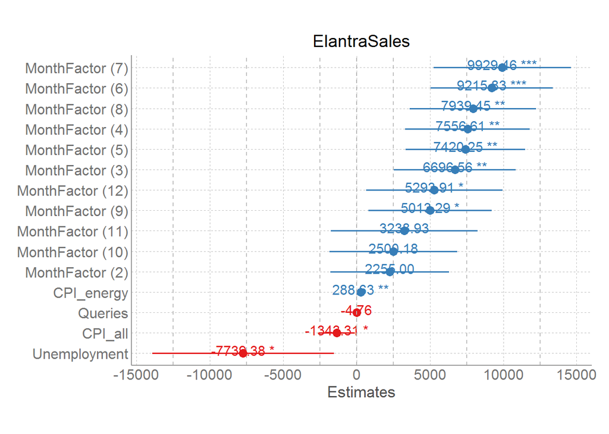

```r
#What is the model R-Squared?
#Ans:0.8193

##############################

#PROBLEM 4.2 - SIGNIFICANT VARIABLES

#Which variables are significant, or have levels that are significant? Use 0.10 as your p-value cutoff. (Select all that apply.)
#Ans:Month (the factor version) ,CPI_all,CPI_energy ,Unemployment

#lets plot the coeff to see which are significant using sjPlot library
library(sjPlot)
#?sjp.lm
sjp.lm(ElantraLM,type="lm")
```

```r
#################################

#PROBLEM 5.1 - MULTICOLINEARITY

#Another peculiar observation about the regression is that the sign of the Queries variable has changed. In particular, when we naively modeled Month as a numeric variable, Queries had a positive coefficient. Now, Queries has a negative coefficient. Furthermore, CPI_energy has a positive coefficient -- as the overall price of energy increases, we expect Elantra sales to increase, which seems counter-intuitive (if the price of energy increases, we'd expect consumers to have less funds to purchase automobiles, leading to lower Elantra sales).

#As we have seen before, changes in coefficient signs and signs that are counter to our intuition may be due to a multicolinearity problem. To check, compute the correlations of the variables in the training set.
cor(ElantraTrain[c("Unemployment","Month","Queries","CPI_energy","CPI_all")])  #or
```

```
##              Unemployment      Month    Queries CPI_energy    CPI_all
## Unemployment    1.0000000 -0.2036029 -0.6411093 -0.8007188 -0.9562123
## Month          -0.2036029  1.0000000  0.0158443  0.1760198  0.2667883
## Queries        -0.6411093  0.0158443  1.0000000  0.8328381  0.7536732
## CPI_energy     -0.8007188  0.1760198  0.8328381  1.0000000  0.9132259
## CPI_all        -0.9562123  0.2667883  0.7536732  0.9132259  1.0000000
```

```r
cor(ElantraTrain$CPI_energy,ElantraTrain[,1:7]) #last col i.e.MonthFactor is a factor var and hence not be included for getting correlation as only numeric var can be computed
```

```
##          Month      Year ElantraSales Unemployment   Queries CPI_energy
## [1,] 0.1760198 0.8316052    0.5916491   -0.8007188 0.8328381          1
##        CPI_all
## [1,] 0.9132259
```

```
## Computing correlation using spearman-method with listwise-deletion...
```

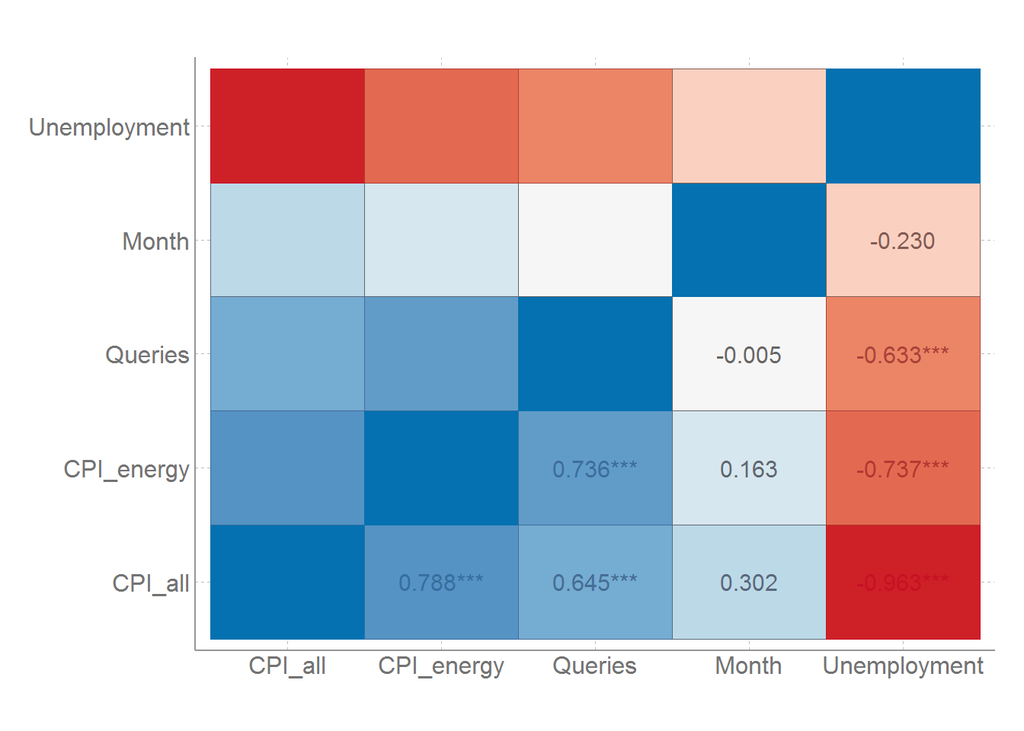

```r
#Which of the following variables is CPI_energy highly correlated with? Select all that apply. (Include only variables where the absolute value of the correlation exceeds 0.6. For the purpose of this question, treat Month as a numeric variable, not a factor variable.)
#Ans:Unemployment,Queries,CPI_all

#plotting the correlation matrix
library(sjPlot)
#?sjp.corr
sjp.corr(ElantraTrain[,c("Unemployment","Month","Queries","CPI_energy","CPI_all")],type = "tile",show.legend=FALSE)
```

```
## Removed 0 cases during 0 step(s).
## R^2 / adj. R^2 of original model: 0.819264 / 0.683712
## R^2 / adj. R^2 of updated model:  0.819264 / 0.683712
## AIC of original model: 672.515747
## AIC of updated model:  672.515747
```

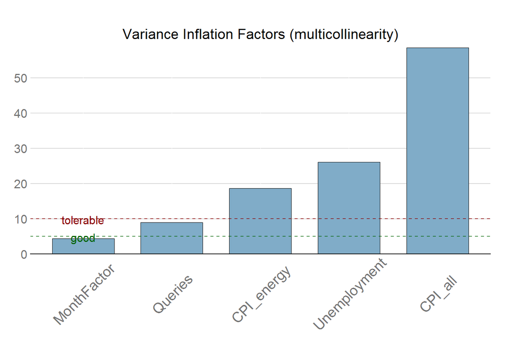

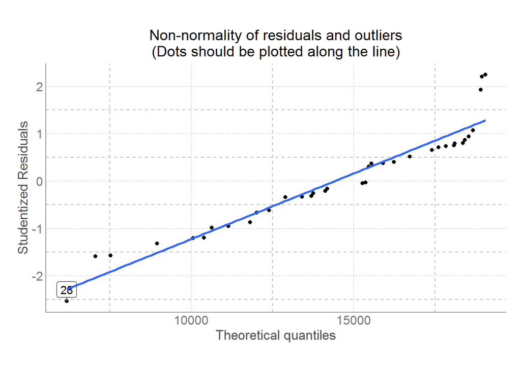

[figure not shown]

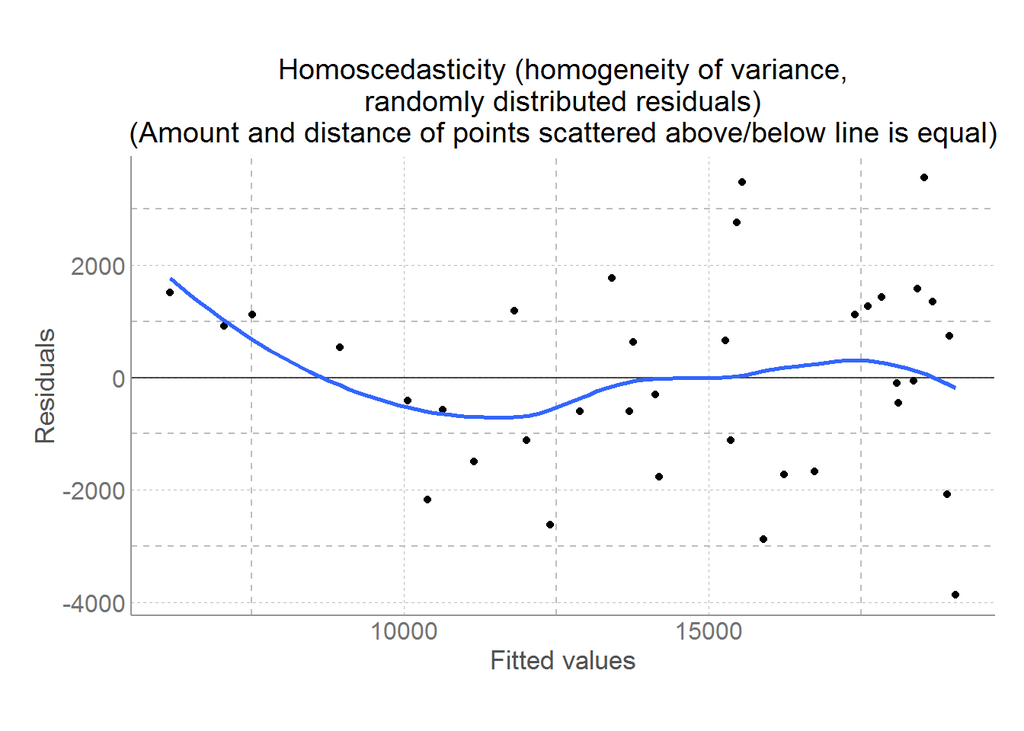

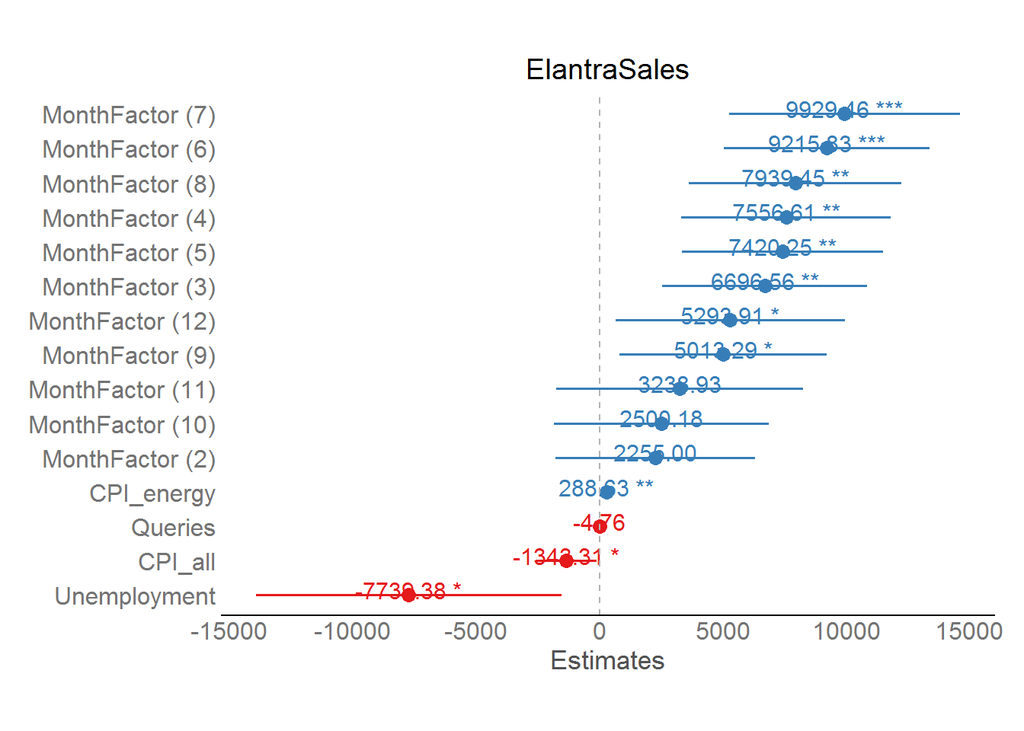

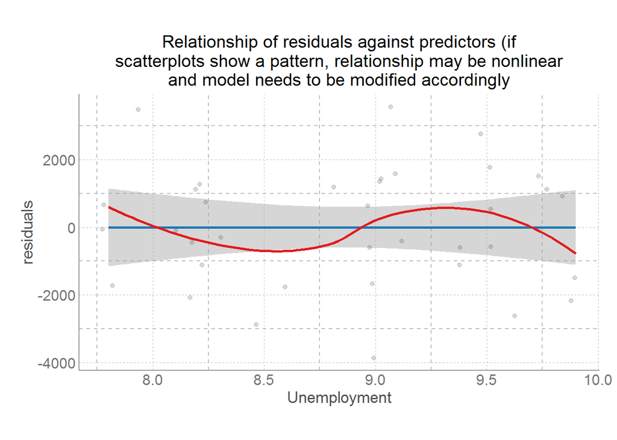

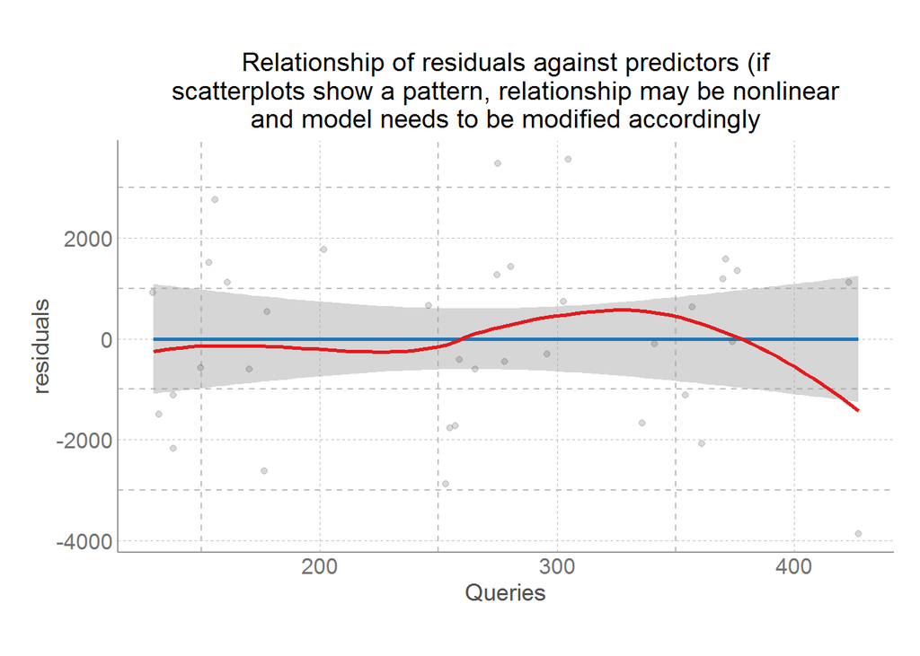

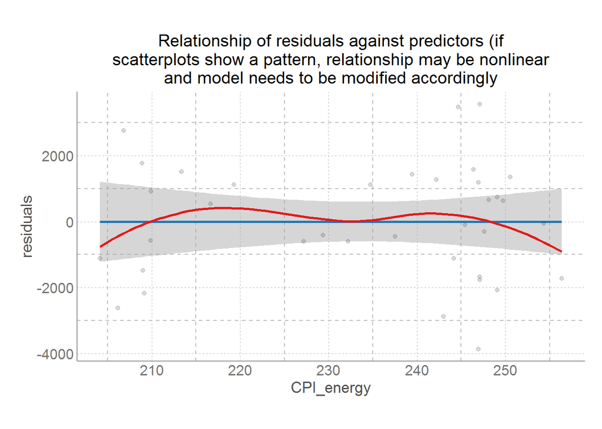

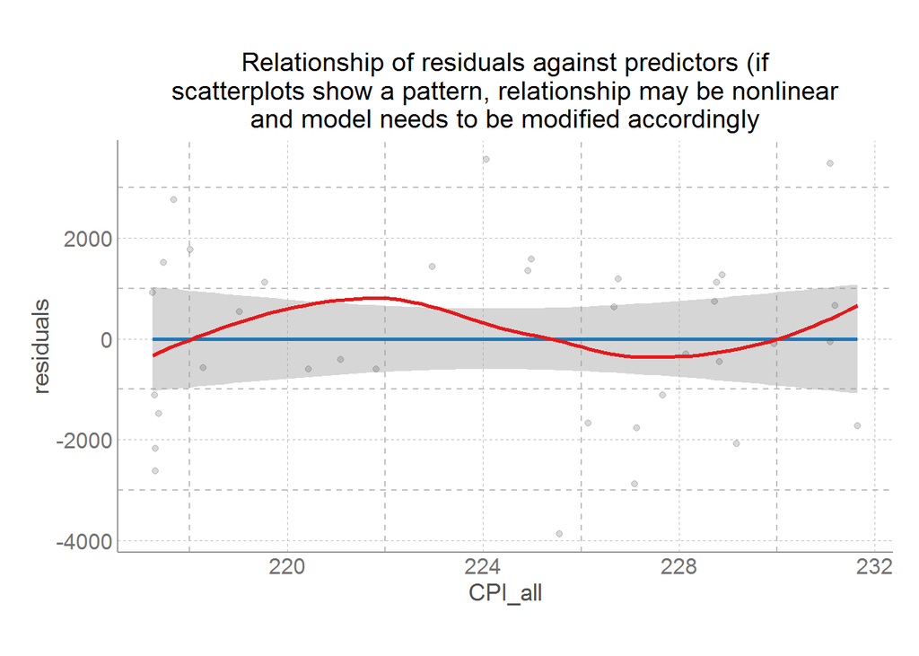

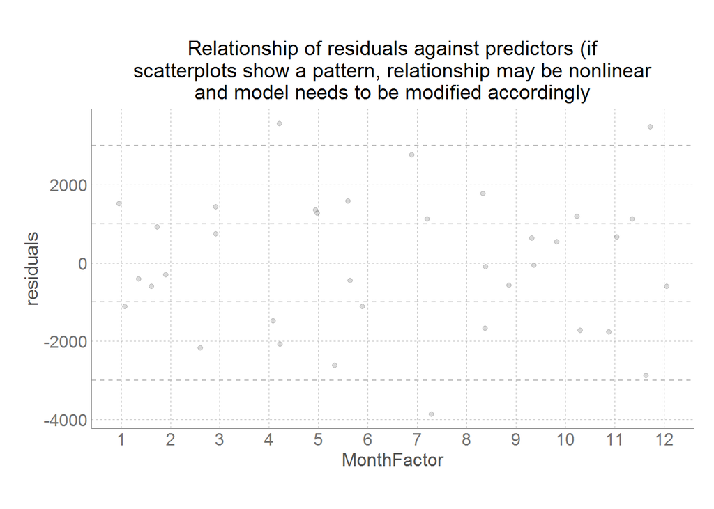

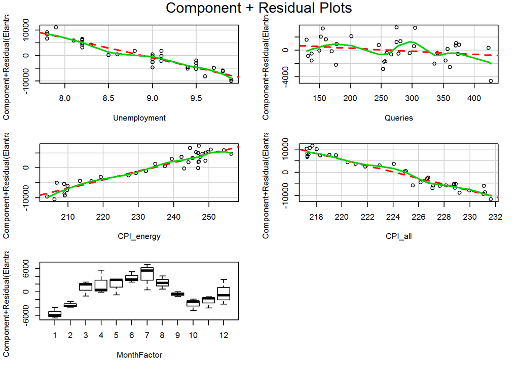

[figure not shown]

```
##  lag Autocorrelation D-W Statistic p-value
##    1      -0.4653687      2.795112   0.476
##  Alternative hypothesis: rho != 0
```

[3 more figures not shown]

```
##
## Suggested power transformation:  0.6030641
```

```r
#Testing the model assumptions
library(sjPlot)
#?sjp.lm
sjp.lm(ElantraLM,type="ma",completeDiagnostic=T)
```

```r
#the plots are giving a real & strong indication of presence of multicollinearity

#########################################

#PROBLEM 5.2 - CORRELATIONS

#Which of the following variables is Queries highly correlated with? Again, compute the correlations on the training set. Select all that apply. (Include only variables where the absolute value of the correlation exceeds 0.6. For the purpose of this question, treat Month as a numeric variable, not a factor variable.)
cor(ElantraTrain[c("Unemployment","Month","Queries","CPI_energy","CPI_all")])  #or
```

```
##              Unemployment      Month    Queries CPI_energy    CPI_all
## Unemployment    1.0000000 -0.2036029 -0.6411093 -0.8007188 -0.9562123
## Month          -0.2036029  1.0000000  0.0158443  0.1760198  0.2667883
## Queries        -0.6411093  0.0158443  1.0000000  0.8328381  0.7536732
## CPI_energy     -0.8007188  0.1760198  0.8328381  1.0000000  0.9132259
## CPI_all        -0.9562123  0.2667883  0.7536732  0.9132259  1.0000000
```

```r
cor(ElantraTrain$Queries,ElantraTrain[,1:7]) #last col
```

```
##          Month     Year ElantraSales Unemployment Queries CPI_energy
## [1,] 0.0158443 0.726531    0.6100645   -0.6411093       1  0.8328381
##        CPI_all
## [1,] 0.7536732
```

```
## Computing correlation using spearman-method with listwise-deletion...
```

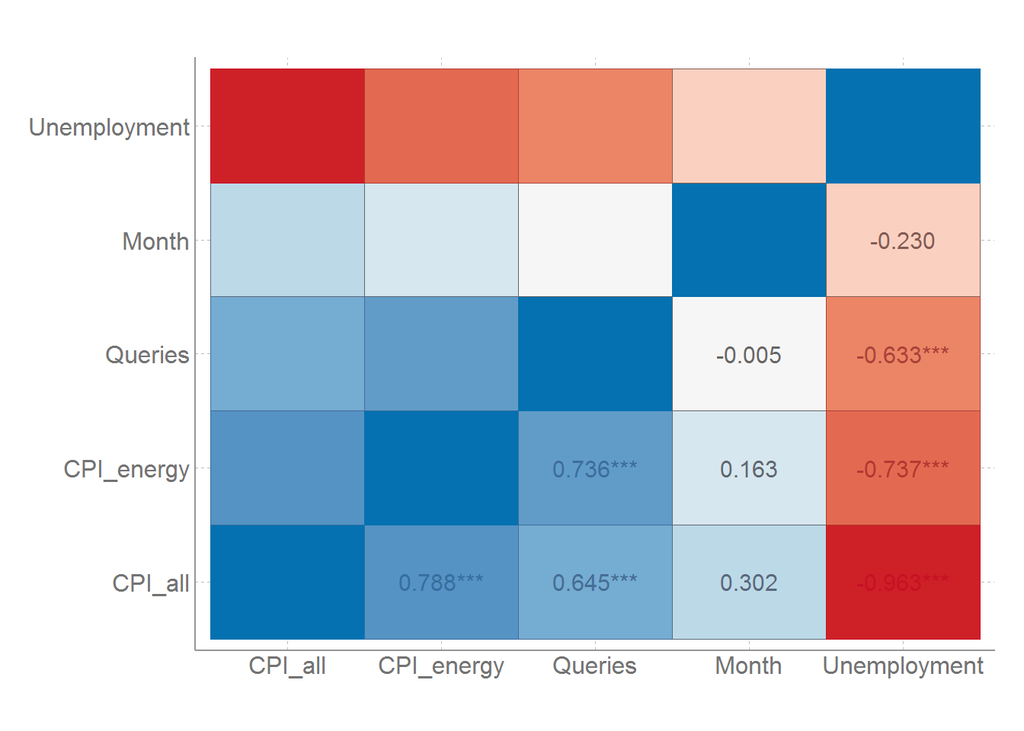

```r
#Ans:Unemployment,CPI_energy,CPI_all

#plotting the correlation matrix
library(sjPlot)
#?sjp.corr
sjp.corr(ElantraTrain[,c("Unemployment","Month","Queries","CPI_energy","CPI_all")],type = "tile",show.legend =FALSE)
```

```r
##############################

#PROBLEM 6.1 - A REDUCED MODEL

#Let us now simplify our model (the model using the factor version of the Month variable). We will do this by iteratively removing variables, one at a time. Remove the variable with the highest p-value (i.e., the least statistically significant variable) from the model. Repeat this until there are no variables that are insignificant or variables for which all of the factor levels are insignificant. Use a threshold of 0.10 to determine whether a variable is significant.

#Method1:AUTOMATICALLY BUILDING THE MODEL
StepModel<-step(ElantraLM)
```

```
## Start:  AIC=568.35
## ElantraSales ~ Unemployment + Queries + CPI_energy + CPI_all +
##     MonthFactor
##
##                Df Sum of Sq       RSS    AIC
## - Queries       1    720829 107064906 566.60
## <none>                      106344077 568.35
## - CPI_all       1  27292499 133636576 574.58
## - Unemployment  1  36136773 142480850 576.88
## - CPI_energy    1  46147903 152491980 579.33
## - MonthFactor  11 230125737 336469814 587.82
##
## Step:  AIC=566.6
## ElantraSales ~ Unemployment + CPI_energy + CPI_all + MonthFactor
##
##                Df Sum of Sq       RSS    AIC
## <none>                      107064906 566.60
## - CPI_all       1  29428416 136493322 573.34
## - Unemployment  1  40143086 147207993 576.06
## - CPI_energy    1  59057377 166122283 580.41
## - MonthFactor  11 260411263 367476169 588.99
```

```r
summary(StepModel)
```

```
##
## Call:
## lm(formula = ElantraSales ~ Unemployment + CPI_energy + CPI_all +
##     MonthFactor, data = ElantraTrain)
##
## Residuals:
##     Min      1Q  Median      3Q     Max
## -3866.0 -1283.3  -107.2  1098.3  3650.1
##
## Coefficients:
##                Estimate Std. Error t value Pr(>|t|)
## (Intercept)   325709.15  136627.85   2.384 0.026644 *
## Unemployment   -7971.34    2840.79  -2.806 0.010586 *
## CPI_energy       268.03      78.75   3.403 0.002676 **
## CPI_all        -1377.58     573.39  -2.403 0.025610 *
## MonthFactor2    2410.91    1857.10   1.298 0.208292
## MonthFactor3    6880.09    1888.15   3.644 0.001517 **
## MonthFactor4    7697.36    1960.21   3.927 0.000774 ***
## MonthFactor5    7444.64    1908.48   3.901 0.000823 ***
## MonthFactor6    9223.13    1953.64   4.721 0.000116 ***
## MonthFactor7    9602.72    2012.66   4.771 0.000103 ***
## MonthFactor8    7919.50    2020.99   3.919 0.000789 ***
## MonthFactor9    5074.29    1962.23   2.586 0.017237 *
## MonthFactor10   2724.24    1951.78   1.396 0.177366
## MonthFactor11   3665.08    2055.66   1.783 0.089062 .
## MonthFactor12   5643.19    1974.36   2.858 0.009413 **
## ---
## Signif. codes:  0 '***' 0.001 '**' 0.01 '*' 0.05 '.' 0.1 ' ' 1
##
## Residual standard error: 2258 on 21 degrees of freedom
## Multiple R-squared:  0.818,  Adjusted R-squared:  0.6967
## F-statistic: 6.744 on 14 and 21 DF,  p-value: 5.73e-05
```